# ANALISIS PRINCIPAL COMPONENTS DATASET HOUSES

JGB1970

2022-08-31

```r
library(dplyr)
library(tidyr)
library(ggplot2)
library(performance)
library(moments)
library(RColorBrewer)
library(fastDummies)
library(glmnet)
library(ISLR)
library(recipes)
library(rsample)
library(glmnetUtils)
library(caret)
library(openxlsx)
library(writexl)
library(corrplot)
library(car)
library(olsrr)
library(GGally)
library(MASS)
library(tseries)
library(naniar)
library(ggpubr)
library(broom)
library(lmtest)
library(leaps)
library(recipes)
select <- dplyr::select
library(circlize)
library(FactoMineR)
library(factoextra)
```

```r
df <- read.csv("C:\\Users\\JULIAN\\Desktop\\CLASES DE R\\EJERCICIOS CLASE\\clases\\data\\kc_house_data.csv")
df <- df %>% select(everything(), -id,-date)
df$bathrooms <-  as.integer(df$bathrooms)
df$floors <-  as.integer(df$floors)
```

Para el modelo PCA, modifico la clase de algunas variables.

```r
dfpc <- df %>% mutate(
  condition = as.character(condition),
  grade = as.character(grade),
  waterfront = as.character(waterfront),
  zipcode = factor(zipcode)
)
```

En el caso de condition y grade, al haber pocos registros para determinados niveles, lo que he hecho ha sido reordenarlos y/o agruparlos para que los grupos sean más compactos y numerosos, ya que si no, tenía errores al generar los check_models

Aqui sumo los 30 registros de la condición 1 a los 172 de la condicion 2. En el caso de la variable grade, reduzco de 13 a 10 las categorías existentes.

```r
dfpc <- mutate(dfpc, condition = ifelse(condition == 1,2,condition))

dfpc$grade <- ntile(dfpc$grade, 10)
```

He quitado también las variables yr_renovated y view, porque en repetidas simulaciones, y analizando la composición y graficando veía que era posible que influyeran en el modelo negativamente por su escasa información.

```r
dfpc <- dfpc %>% select(everything(), -yr_renovated, -view)
```

Aqui genero un train y un test.

```r
set.seed(1234)
split <- initial_split(data = dfpc, prop = 0.9)
train <- training(split)
test <- testing(split)
```

Elijo las variables numéricas con las que trabaja el método PCA.

```r
train_num <- train %>%
  select(where(is.numeric), - c(price))
```

Creo el modelo con el subconjunto train.

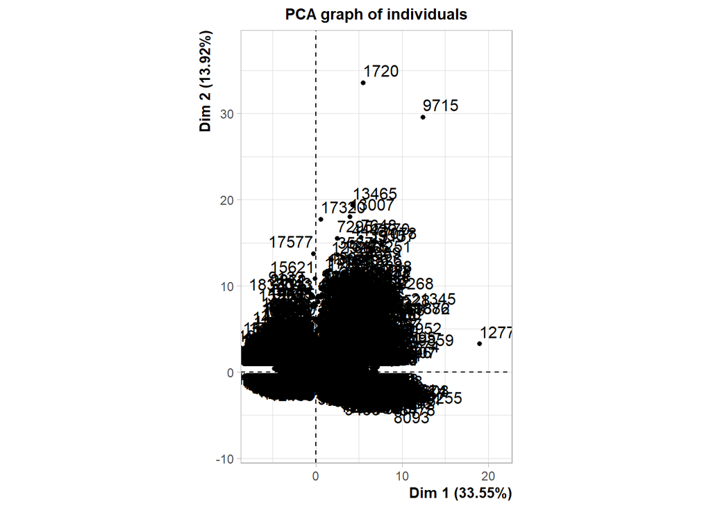

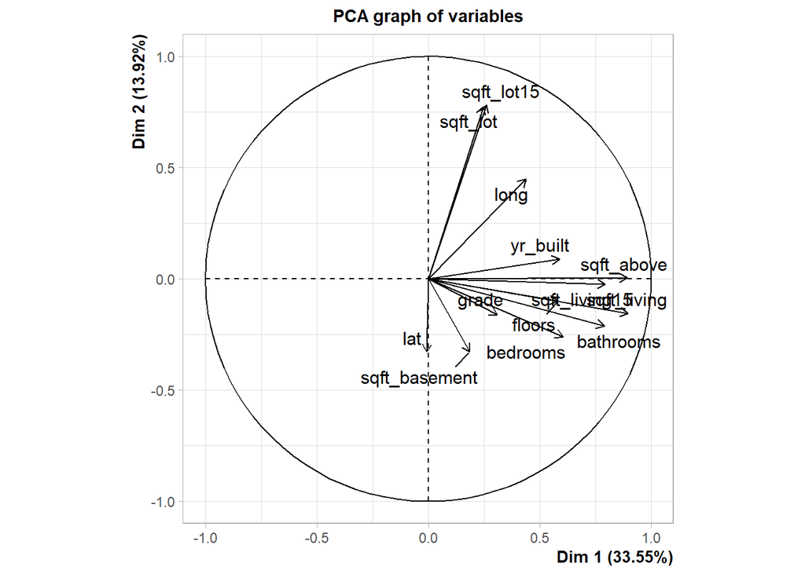

```r
dfpca = PCA(train_num, scale.unit = T,
          graph = T,
          ncp = ncol(train_num) - 1)
```

Obtenemos gráficamente la contribución de cada una de las dimensiones a la explicación de la varianza.

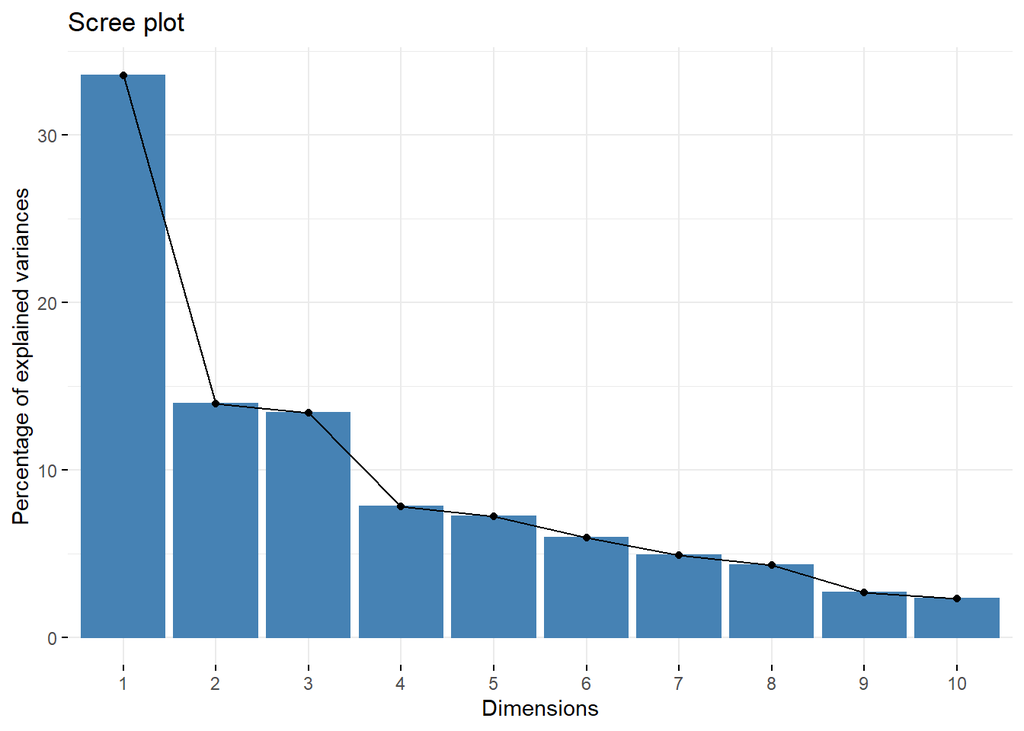

```r
fviz_screeplot(dfpca)
```

En esta tabla, obtenemos los valores numéricos reflejados en el gráfico anterior.

```r
dfpca$eig
```

```
##           eigenvalue percentage of variance cumulative percentage of variance
## comp 1  4.360996e+00           3.354612e+01                          33.54612
## comp 2  1.810135e+00           1.392412e+01                          47.47024
## comp 3  1.742751e+00           1.340578e+01                          60.87602
## comp 4  1.016556e+00           7.819664e+00                          68.69568
## comp 5  9.387226e-01           7.220943e+00                          75.91662
## comp 6  7.709234e-01           5.930180e+00                          81.84680
## comp 7  6.338177e-01           4.875521e+00                          86.72232
## comp 8  5.566288e-01           4.281760e+00                          91.00408
## comp 9  3.473281e-01           2.671755e+00                          93.67584
## comp 10 2.999240e-01           2.307108e+00                          95.98295
## comp 11 2.946314e-01           2.266395e+00                          98.24934
## comp 12 2.275856e-01           1.750659e+00                         100.00000
## comp 13 4.349256e-28           3.345582e-27                         100.00000
```

Aqui vemos la aportación de cada uno de las variables a cada una de las dimensiones.

```r
var <- get_pca_var(dfpca)
head(var$contrib, 20)
```

```
##                      Dim.1        Dim.2       Dim.3        Dim.4       Dim.5
## bedrooms       8.387656366  3.771196348  5.26917738  4.580273793  1.68477666
## bathrooms     14.316561312  2.476471794  0.06308611  0.003014946  0.04805277
## sqft_living   18.409015772  1.320630830  5.48901949  0.226606975  0.62258163
## sqft_lot       1.396060953 33.151905352  5.26680312  5.620290594  1.14429541
## floors         7.725612226  0.555319007 19.10069946  4.278916560  0.48273212
## grade          2.198979698  1.424256541  6.05923648 13.648029375 51.32235860
## sqft_above    18.323161022  0.001051788  0.10471864  0.106180537  8.58430009
## sqft_basement  0.798329638  5.950985192 29.74498136  0.142373747 14.70288976
## yr_built       7.977678494  0.444824569 17.82742664  0.242806297  3.48054096
## lat            0.001337508  5.978089156  1.66302901 61.560927488 12.87576398
## long           4.405251509 11.135137362  2.79432080  4.458930739  0.77345790
## sqft_living15 14.479036276  0.033381494  1.44126895  0.023236016  3.25828307
## sqft_lot15     1.581319225 33.756750567  5.17623256  5.108412934  1.01996705
##                      Dim.6        Dim.7       Dim.8       Dim.9      Dim.10
## bedrooms       0.001572155 1.904690e+01 45.79372801  8.32427450  0.05538504
## bathrooms      6.231834066 8.673177e+00  3.26499794 37.10759919 21.85714172
## sqft_living    0.099265420 7.706088e-04  3.28449975  0.01177190  1.48899204
## sqft_lot       3.849198860 1.168892e-03  1.21494604  1.21872994  8.72294848
## floors        13.610825278 1.778675e+00  0.76816994  0.01267544 36.18036133
## grade          3.970391119 1.428218e+01  3.38050227  3.05093242  0.21309501
## sqft_above     0.889097184 7.062856e+00  2.38015172  0.20248910  0.07387545
## sqft_basement  1.226505644 2.403159e+01  0.76132777  0.37843708  9.20073781
## yr_built       0.418883451 2.124421e+01  1.04715024 30.00870578  7.53812188
## lat            9.264005093 9.267748e-01  5.98232295  0.75321915  0.57492359
## long          54.055156114 1.320314e+00  4.77403688  9.84827060  4.15288018
## sqft_living15  4.560706550 1.631254e+00 27.31925736  5.41421474  0.25868387
## sqft_lot15     1.822559066 1.249213e-04  0.02890914  3.66868016  9.68285360
##                     Dim.11      Dim.12
## bedrooms       0.015192255  3.06986540
## bathrooms      0.087009799  5.87105356
## sqft_living    0.001599728 20.17107248
## sqft_lot      37.433315667  0.98033669
## floors        11.636926335  3.86908763
## grade          0.001692023  0.44834777
## sqft_above     0.454526749 22.09672553
## sqft_basement  1.381520598  0.27536103
## yr_built       8.104997224  1.66464953
## lat            0.285301051  0.13430624
## long           2.265112253  0.01713165
## sqft_living15  0.368739216 41.21193883
## sqft_lot15    37.964067101  0.19012367
```

En estos gráficos visualizamos esa aportación en las dos primeras dimensiones.

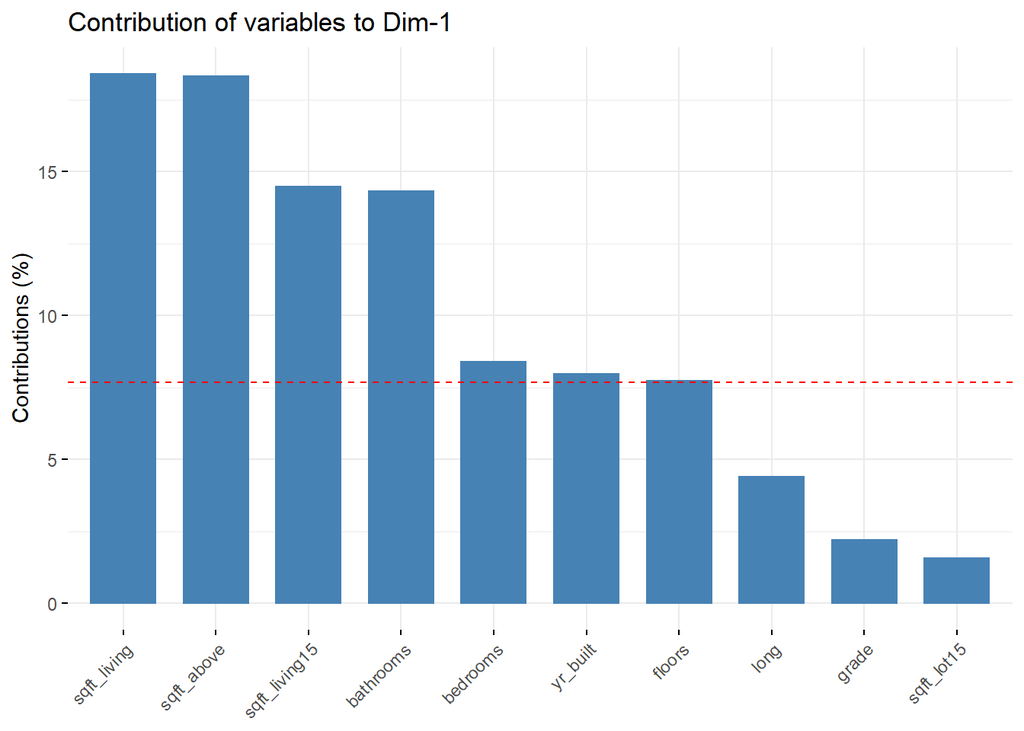

```r
fviz_contrib(dfpca, choice = "var", axes = 1, top = 10)
```

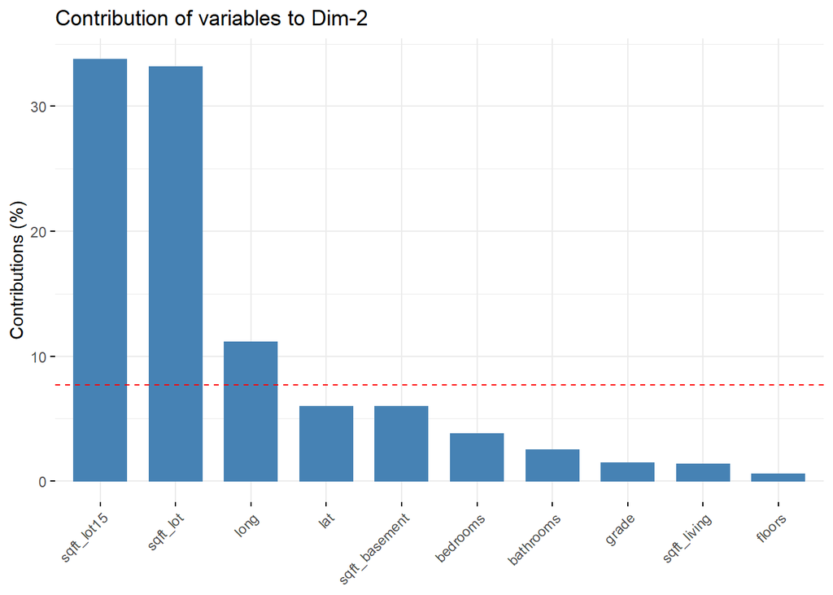

```r
fviz_contrib(dfpca, choice = "var", axes = 2, top = 10)
```

```r
pcavartrain <- predict(dfpca, newdata = train)
pcavartrain <- as.data.frame(pcavartrain$coord)
train_generadopca <- bind_cols(train, pcavartrain)
```

Creo varios modelos para analizar y comparar.

```r
modelpca <- lm(log(price)~Dim.1 + Dim.2 + Dim.3 + Dim.5  +condition + grade+ zipcode + waterfront  , data = train_generadopca, na.action= na.exclude)
summary(modelpca)
```

```
##
## Call:
## lm(formula = log(price) ~ Dim.1 + Dim.2 + Dim.3 + Dim.5 + condition +
##     grade + zipcode + waterfront, data = train_generadopca, na.action = na.exclude)
##
## Residuals:
##      Min       1Q   Median       3Q      Max
## -1.79443 -0.10914  0.00421  0.11222  1.12697
##
## Coefficients:
##               Estimate Std. Error t value Pr(>|t|)
## (Intercept)  12.195780   0.019634 621.146  < 2e-16 ***
## Dim.1         0.130780   0.001065 122.823  < 2e-16 ***
## Dim.2        -0.003665   0.001452  -2.524 0.011609 *
## Dim.3         0.099189   0.001754  56.551  < 2e-16 ***
## Dim.5        -0.161946   0.003507 -46.181  < 2e-16 ***
## condition3    0.211665   0.015698  13.483  < 2e-16 ***
## condition4    0.246490   0.015795  15.606  < 2e-16 ***
## condition5    0.295237   0.016414  17.986  < 2e-16 ***
## grade         0.052538   0.001249  42.052  < 2e-16 ***
## zipcode98002 -0.071527   0.019348  -3.697 0.000219 ***
## zipcode98003  0.040916   0.017248   2.372 0.017691 *
## zipcode98004  0.968720   0.017119  56.586  < 2e-16 ***
## zipcode98005  0.566417   0.020491  27.642  < 2e-16 ***
## zipcode98006  0.534696   0.015454  34.599  < 2e-16 ***
## zipcode98007  0.475674   0.021680  21.941  < 2e-16 ***
## zipcode98008  0.478148   0.017587  27.187  < 2e-16 ***
## zipcode98010  0.174972   0.024663   7.094 1.34e-12 ***
## zipcode98011  0.191317   0.019930   9.599  < 2e-16 ***
## zipcode98014  0.028827   0.023216   1.242 0.214362
## zipcode98019  0.010854   0.019827   0.547 0.584087
## zipcode98022  0.045912   0.018358   2.501 0.012398 *
## zipcode98023 -0.005484   0.014919  -0.368 0.713155
## zipcode98024  0.182308   0.026942   6.767 1.36e-11 ***
## zipcode98027  0.357021   0.015818  22.570  < 2e-16 ***
## zipcode98028  0.182298   0.017873  10.200  < 2e-16 ***
## zipcode98029  0.433921   0.016833  25.778  < 2e-16 ***
## zipcode98030 -0.005072   0.017718  -0.286 0.774693
## zipcode98031  0.002219   0.017343   0.128 0.898189
## zipcode98032 -0.054121   0.022293  -2.428 0.015205 *
```

[output cut: 41 more lines]

```
## zipcode98155  0.197529   0.016292  12.124  < 2e-16 ***
## zipcode98166  0.256522   0.017647  14.536  < 2e-16 ***
## zipcode98168 -0.040767   0.017465  -2.334 0.019594 *
## zipcode98177  0.432714   0.018802  23.014  < 2e-16 ***
## zipcode98178  0.037030   0.017756   2.085 0.037039 *
## zipcode98188  0.023343   0.021798   1.071 0.284237
## zipcode98198  0.046915   0.017321   2.709 0.006763 **
## zipcode98199  0.764282   0.017517  43.631  < 2e-16 ***
## waterfront1   0.735891   0.017223  42.728  < 2e-16 ***
## ---
## Signif. codes:  0 '***' 0.001 '**' 0.01 '*' 0.05 '.' 0.1 ' ' 1
##
## Residual standard error: 0.2042 on 19372 degrees of freedom
## Multiple R-squared:  0.8503, Adjusted R-squared:  0.8497
## F-statistic:  1411 on 78 and 19372 DF,  p-value: < 2.2e-16
```

En este modelo, el VIF del zipcode sale un poco alto.

```r
vif(modelpca)
```

```
##                GVIF Df GVIF^(1/(2*Df))
## Dim.1      2.305388  1        1.518351
## Dim.2      1.779382  1        1.333935
## Dim.3      2.499880  1        1.581101
## Dim.5      5.382623  1        2.320048
## condition  1.367357  3        1.053530
## grade      6.008147  1        2.451152
## zipcode    7.529161 69        1.014736
## waterfront 1.058339  1        1.028756
```

Voy a coger sólo las tres primeras dimensiones manteniendo zipcode.

```r
modelpca <- lm(log(price)~Dim.1 + Dim.2 + Dim.3 + condition +grade + waterfront + zipcode  , data = train_generadopca, na.action= na.exclude)
summary(modelpca)
```

```
##
## Call:
## lm(formula = log(price) ~ Dim.1 + Dim.2 + Dim.3 + condition +
##     grade + waterfront + zipcode, data = train_generadopca, na.action = na.exclude)
##
## Residuals:
##      Min       1Q   Median       3Q      Max
## -1.89422 -0.11541  0.00062  0.11860  1.19741
##
## Coefficients:
##                Estimate Std. Error t value Pr(>|t|)
## (Intercept)  12.3551048  0.0203645 606.699  < 2e-16 ***
## Dim.1         0.1517813  0.0010144 149.632  < 2e-16 ***
## Dim.2        -0.0020811  0.0015293  -1.361 0.173609
## Dim.3         0.0504322  0.0014757  34.176  < 2e-16 ***
## condition3    0.1859421  0.0165292  11.249  < 2e-16 ***
## condition4    0.2398421  0.0166403  14.413  < 2e-16 ***
## condition5    0.2940657  0.0172939  17.004  < 2e-16 ***
## grade         0.0018377  0.0006283   2.925 0.003447 **
## waterfront1   0.7690218  0.0181297  42.418  < 2e-16 ***
## zipcode98002 -0.0705727  0.0203849  -3.462 0.000537 ***
## zipcode98003  0.0489152  0.0181713   2.692 0.007111 **
## zipcode98004  1.1676449  0.0174564  66.889  < 2e-16 ***
## zipcode98005  0.7550231  0.0211557  35.689  < 2e-16 ***
## zipcode98006  0.6843956  0.0159201  42.989  < 2e-16 ***
## zipcode98007  0.6415018  0.0225258  28.479  < 2e-16 ***
## zipcode98008  0.6393862  0.0181610  35.207  < 2e-16 ***
## zipcode98010  0.1925208  0.0259816   7.410 1.32e-13 ***
## zipcode98011  0.4243245  0.0203140  20.888  < 2e-16 ***
## zipcode98014  0.1934740  0.0241699   8.005 1.26e-15 ***
## zipcode98019  0.2082431  0.0203976  10.209  < 2e-16 ***
## zipcode98022  0.0007797  0.0193147   0.040 0.967802
## zipcode98023 -0.0024589  0.0157178  -0.156 0.875686
## zipcode98024  0.3184265  0.0282151  11.286  < 2e-16 ***
## zipcode98027  0.4576852  0.0165068  27.727  < 2e-16 ***
## zipcode98028  0.4036706  0.0181407  22.252  < 2e-16 ***
## zipcode98029  0.5659078  0.0174776  32.379  < 2e-16 ***
## zipcode98030  0.0220424  0.0186573   1.181 0.237444
## zipcode98031  0.0406018  0.0182511   2.225 0.026118 *
## zipcode98032 -0.0218655  0.0234764  -0.931 0.351667
```

[output cut: 40 more lines]

```
## zipcode98148  0.1969149  0.0327405   6.014 1.84e-09 ***
## zipcode98155  0.4240130  0.0163691  25.903  < 2e-16 ***
## zipcode98166  0.3584764  0.0184469  19.433  < 2e-16 ***
## zipcode98168  0.0639124  0.0182452   3.503 0.000461 ***
## zipcode98177  0.6820153  0.0189759  35.941  < 2e-16 ***
## zipcode98178  0.1406389  0.0185574   7.579 3.65e-14 ***
## zipcode98188  0.0916467  0.0229127   4.000 6.36e-05 ***
## zipcode98198  0.0951685  0.0182158   5.224 1.76e-07 ***
## zipcode98199  0.9472468  0.0179771  52.692  < 2e-16 ***
## ---
## Signif. codes:  0 '***' 0.001 '**' 0.01 '*' 0.05 '.' 0.1 ' ' 1
##
## Residual standard error: 0.2152 on 19373 degrees of freedom
## Multiple R-squared:  0.8338, Adjusted R-squared:  0.8331
## F-statistic:  1262 on 77 and 19373 DF,  p-value: < 2.2e-16
```

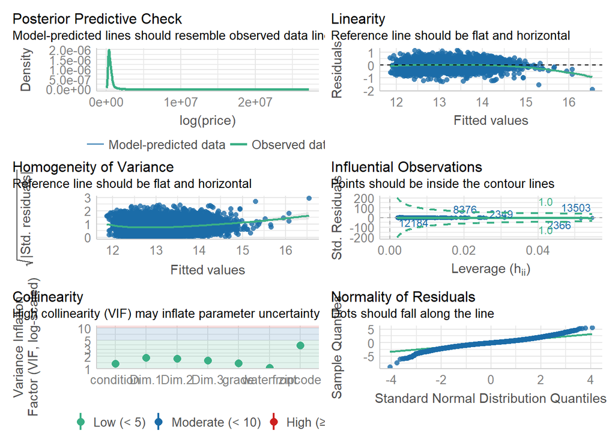

```r
check_model(modelpca)
```

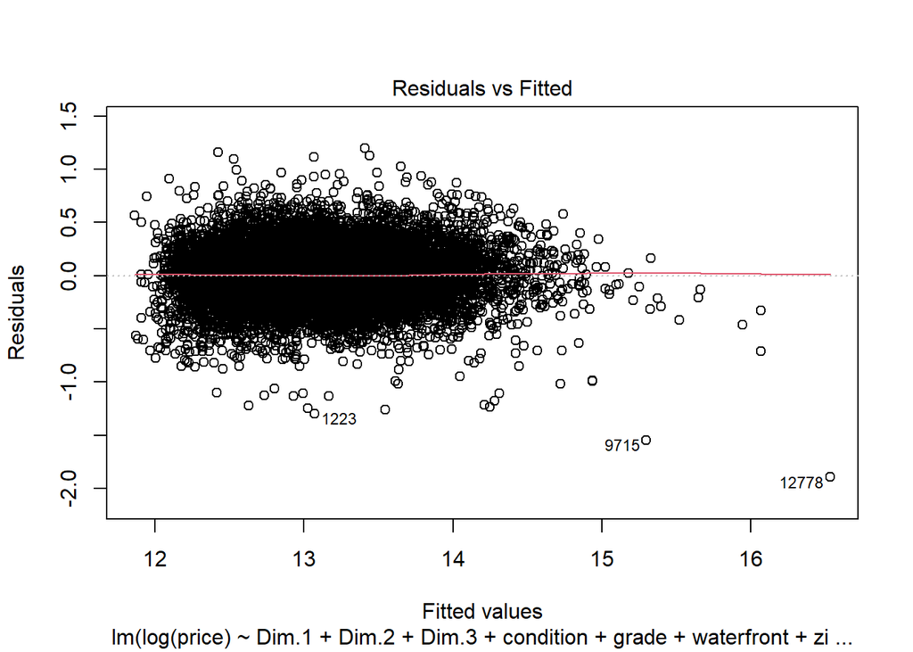

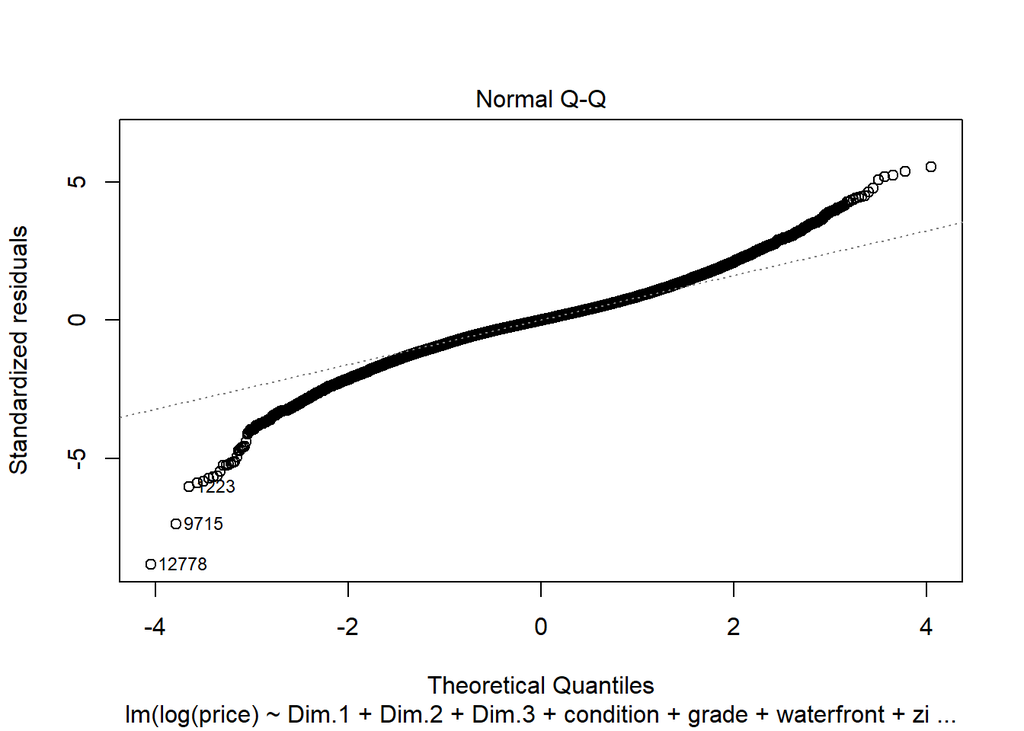

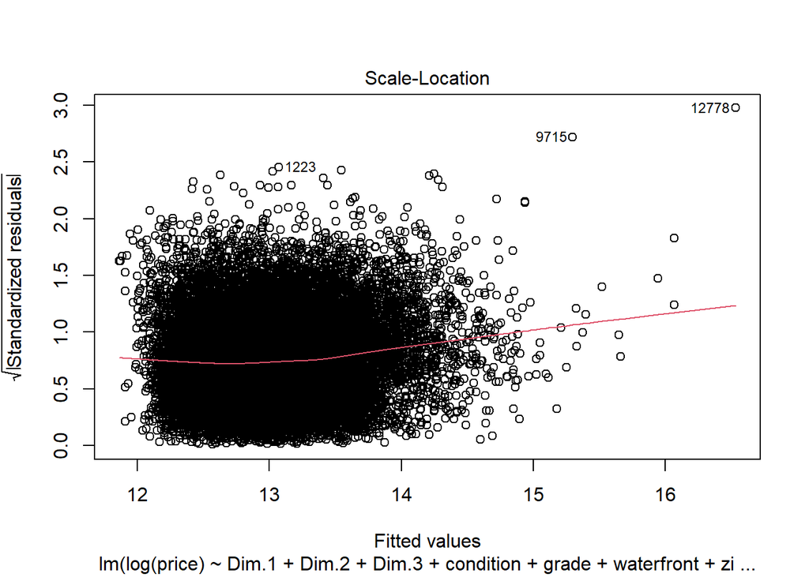

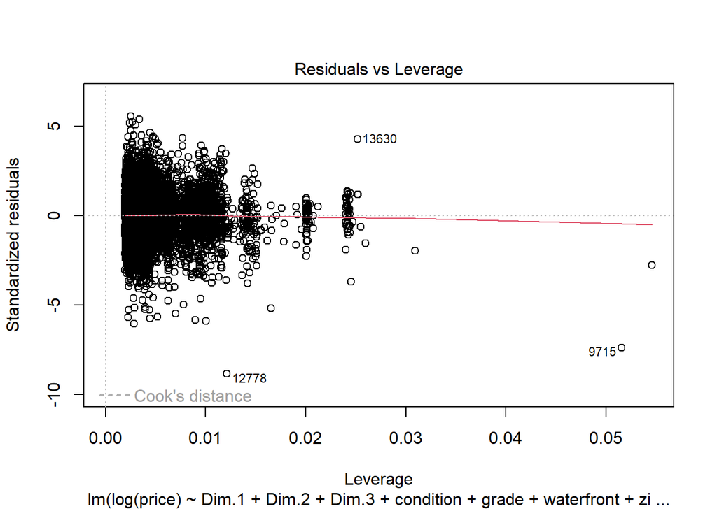

```r
plot(modelpca)
```

```r
vif(modelpca)
```

```
##                GVIF Df GVIF^(1/(2*Df))
## Dim.1      1.884849  1        1.372898
## Dim.2      1.778390  1        1.333563
## Dim.3      1.594098  1        1.262576
## condition  1.344954  3        1.050633
## grade      1.368701  1        1.169915
## waterfront 1.056503  1        1.027863
## zipcode    3.719570 69        1.009564
```

No hay normalidad en los residuos.

```r
moments::jarque.test(modelpca$residuals)
```

```
##
##  Jarque-Bera Normality Test
##
## data:  modelpca$residuals
## JB = 5218.1, p-value < 2.2e-16
## alternative hypothesis: greater
```

Tenemos heterocedasticidad

```r
lmtest::bptest(modelpca)
```

```
##
##  studentized Breusch-Pagan test
##
## data:  modelpca
## BP = 1765.6, df = 77, p-value < 2.2e-16
```

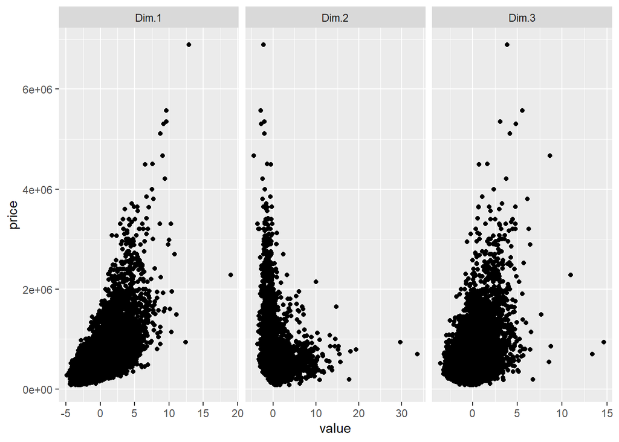

```r
train_generadopca %>% select(Dim.1, Dim.2, Dim.3, price) %>%
  pivot_longer(-price) %>%
  ggplot() +
  geom_point(aes(x = value, y = price)) +
  facet_wrap(~name, scales = 'free_x')
```

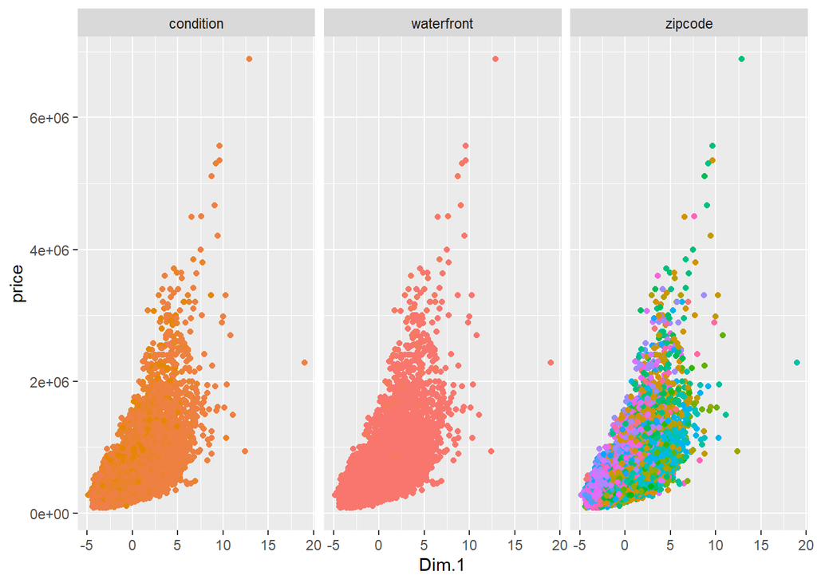

```r
train_generadopca %>%
  select(!where(is.numeric),
         price, Dim.1) %>%
  pivot_longer(-c(price, Dim.1)) %>%
  ggplot() +
  geom_point(aes(x = Dim.1, y = price, col = value)) +
  facet_wrap(~name) + guides(col = FALSE)
```

La segunda también tiene buena pinta.

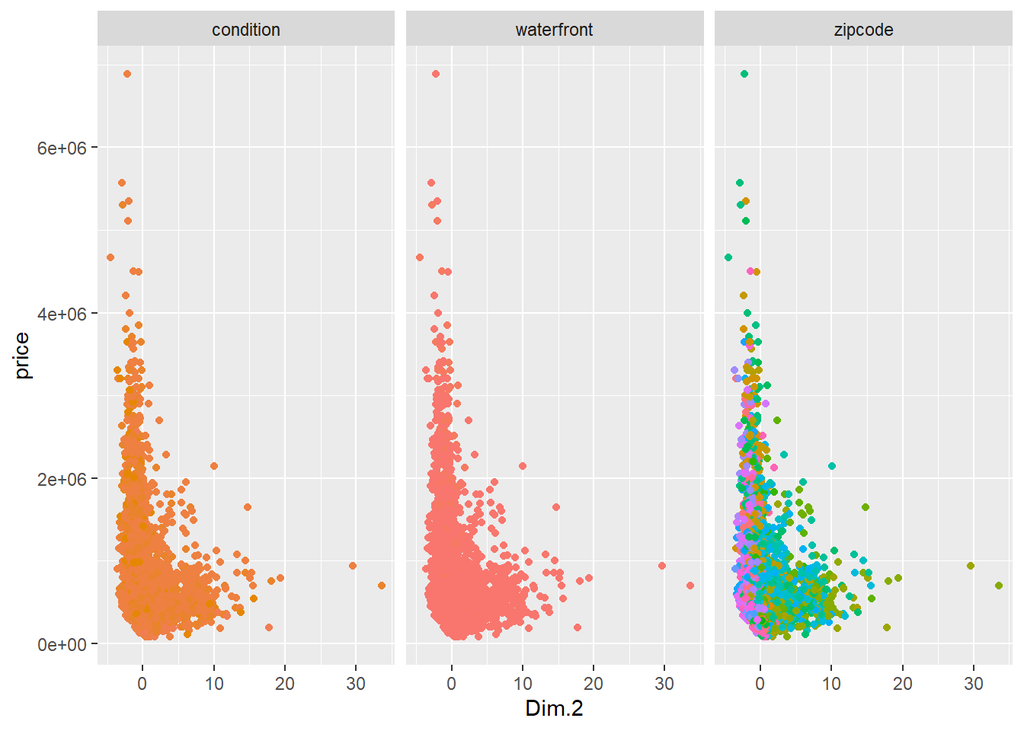

```r
train_generadopca %>%
  select(!where(is.numeric),
         price, Dim.2) %>%
  pivot_longer(-c(price, Dim.2)) %>%
  ggplot() +
  geom_point(aes(x = Dim.2, y = price, col = value)) +
  facet_wrap(~name) + guides(col = FALSE)
```

No se ven patrones.

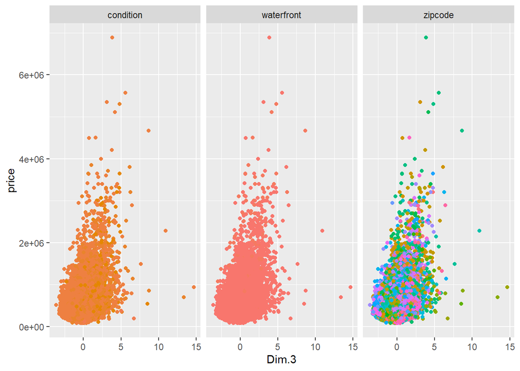

```r
train_generadopca %>%
  select(!where(is.numeric),
         price, Dim.3) %>%
  pivot_longer(-c(price, Dim.3)) %>%
  ggplot() +
  geom_point(aes(x = Dim.3, y = price, col = value)) +
  facet_wrap(~name) + guides(col = FALSE)
```

Ahora paso a las predicciones y a la valoración del modelo. Creo el dataset con los datos del subconjunto test, a través de PCA

```r
pcavartest <- predict(dfpca, newdata = test)
pcavartest <- as.data.frame(pcavartest$coord)
test_generadopca <- bind_cols(test, pcavartest)
```

Hallo la predicción del precio para el dataset test.

```r
preciopcatest <- predict(modelpca, test_generadopca) %>%
  exp()
```

Hallo la predicción del precio para el dataset train.

```r
preciopcatrain <- predict(modelpca, train_generadopca) %>%
  exp()
```

```r
eval_results <- function(true, predicted, df) {
  SSE <- sum((predicted - true)^2)
  SST <- sum((true - mean(true))^2)
  R_square <- 1 - SSE / SST
  RMSE = sqrt(SSE/nrow(df))


  data.frame(
    RMSE = RMSE,
    Rsquare = R_square
  )
}
```

```r
eval_results(train$price, preciopcatrain, train)
```

| RMSE | Rsquare |
| --- | --- |
| 188486.2 | 0.7335812 |

```r
eval_results(test$price, preciopcatest, test)
```

| RMSE | Rsquare |
| --- | --- |
| 200116.3 | 0.7284372 |